# О промышленном производстве в январе-июле 2026 года

[figure not shown]

О ПРОМЫШЛЕННОМ ПРОИЗВОДСТВЕ  
В ЯНВАРЕ-ИЮЛЕ 2026 ГОДА1,2,3

Индекс промышленного производства* составил:

– в январе-июле 2026 г. по сравнению с январем-июлем 2025 г. – 100,1%;

– в июле 2026 г. по сравнению с июлем 2025 г. – 100,4%, по сравнению с июнем 2026 г. – 101,4%.

Индекс промышленного производства  
в % к среднемесячному значению 2023 года

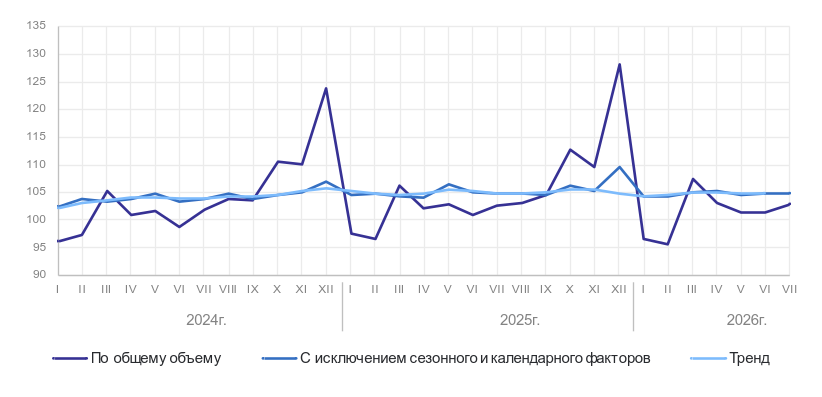

________________________

* Индекс промышленного производства исчисляется по видам деятельности «Добыча полезных ископаемых», «Обрабатывающие производства», «Обеспечение электрической энергией, газом и паром; кондиционирование воздуха», «Водоснабжение; водоотведение, организация сбора и утилизации отходов, деятельность по ликвидации загрязнений» в соответствии с Официальной статистической методологией исчисления индекса промышленного производства (приказ Росстата от 16.01.2020 № 7) на основе данных о динамике производства важнейших товаров-представителей в физическом измерении, оцененных в ценах базисного 2023 года. В качестве весов используется структура валовой добавленной стоимости по видам экономической деятельности 2023 базисного года.

Индексы промышленного производства*

В % к

соответст-  
вующему  
периоду  
предыдущего  
года

предыдущему  
периоду

среднемесячному значению  
2023 г.

фактически

с исключением  
сезонного  
и календарного  
факторов**

фактически

с исключением  
сезонного  
и календарного  
факторов**

2025 г.

## Январь

101,5

78,8

97,6

97,6

104,5

## Февраль

99,4

99,1

100,4

96,7

104,9

## Март

101,0

109,9

99,5

106,3

104,4

## I квартал

100,6

87,3

## Апрель

101,0

96,0

99,8

102,0

104,1

## Май

101,2

100,9

102,2

103,0

106,4

## Июнь

102,3

98,0

98,8

100,9

105,2

## II квартал

101,5

101,7

## I полугодие

101,1

## Июль

100,8

101,7

99,6

102,6

104,7

## Январь-июль

101,0

## Август

99,3

100,4

100,0

103,0

104,8

## Сентябрь

101,1

101,5

99,8

104,6

104,6

## III квартал

100,4

101,4

## Январь-сентябрь

100,8

## Октябрь

101,9

107,7

101,6

112,6

106,2

## Ноябрь

99,7

97,3

99,2

109,6

105,4

## Декабрь

103,5

116,9

103,9

128,1

109,5

## IV квартал

101,8

113,0

## Год

101,1

2026 г.

## Январь

99,2

75,5

95,3

96,7

104,4

## Февраль

98,9

98,8

100,0

95,6

104,4

## Март

101,3

112,5

100,7

107,5

105,0

## I квартал

99,9

85,6

## Апрель

101,3

96,0

100,3

103,2

105,3

## Май

98,6

98,2

99,2

101,3

104,5

## Июнь

100,7

100,1

100,2

101,4

104,7

## II квартал

100,2

102,1

## I полугодие

100,0

## Июль

100,4

101,4

100,1

102,9

104,8

## Январь-июль

100,1

* Данные за 2025 год и с января по июнь 2026 года уточнены в соответствии с регламентом разработки и публикации данных по производству и отгрузке продукции и динамике промышленного производства (приказ Росстата от 18.08.2020г. № 470).

** Оценки данных с исключением сезонного и календарного факторов осуществлены с использованием программы "JDEMETRA+". При поступлении новых данных статистических наблюдений динамика может быть уточнена.

Динамика производства по видам экономической деятельности  
в процентах

Добыча  
полезных  
ископаемых

Обрабатывающие  
производства

Обеспечение  
электрической  
энергией, газом  
и паром;  
кондиционирование  
воздуха

Водоснабжение;  
водоотведение,  
организация сбора  
и утилизации  
отходов,  
деятельность  
по ликвидации  
загрязнений

к соот-  
ветст-  
вующему  
периоду  
преды-  
дущего  
года

к преды-  
дущему  
периоду

к соот-  
ветст-  
вующему  
периоду  
преды-  
дущего  
года

к преды-  
дущему  
периоду

к соот-  
ветст-  
вующему  
периоду  
преды-  
дущего  
года

к преды-  
дущему  
периоду

к соот-  
ветст-  
вующему  
периоду  
преды-  
дущего  
года

к преды-  
дущему  
периоду

2025 г.

## Январь

97,7

93,1

106,2

68,8

93,2

98,0

103,3

73,8

## Февраль

94,2

91,2

103,5

105,7

97,4

94,9

97,7

101,7

## Март

96,5

110,1

104,5

111,9

98,4

96,7

97,2

104,5

## I квартал

96,2

94,0

104,7

81,4

96,2

105,1

99,3

85,0

## Апрель

98,7

96,4

102,5

97,0

102,1

84,8

95,7

102,8

## Май

98,8

102,7

103,1

101,3

99,2

86,7

96,9

102,8

## Июнь

99,3

95,1

104,7

100,8

98,2

87,8

98,3

101,9

## II квартал

98,9

99,7

103,4

107,5

100,0

71,3

97,0

109,1

## I полугодие

97,5

104,0

97,7

98,1

## Июль

99,8

103,2

101,8

100,7

99,4

105,5

95,6

95,4

## Январь-июль

97,8

103,7

97,9

97,7

## Август

97,7

100,3

100,3

100,6

99,7

99,5

96,2

98,3

## Сентябрь

100,4

100,4

101,5

102,0

101,3

102,9

101,3

105,0

## III квартал

99,3

101,0

101,2

102,7

100,1

92,2

97,7

98,0

## Январь-сентябрь

98,1

103,0

98,4

97,9

## Октябрь

101,5

105,7

102,2

107,3

101,9

128,2

98,7

100,5

## Ноябрь

100,3

96,9

99,6

96,5

97,1

107,1

99,4

98,4

## Декабрь

97,9

104,5

107,3

124,4

100,4

116,7

96,1

116,9

## IV квартал

99,8

105,5

103,3

115,0

99,8

144,3

97,9

107,8

## Год

98,6

103,1

98,8

97,9

2026 г.

## Январь

100,3

95,4

97,0

62,2

107,1

104,5

93,6

71,9

## Февраль

100,8

91,6

97,0

105,7

102,6

90,9

95,5

103,7

## Март

100,7

110,1

101,9

117,5

99,3

93,6

96,2

105,3

## I квартал

100,6

94,7

98,8

77,9

103,1

108,6

95,1

82,5

## Апрель

99,7

95,4

102,2

97,4

100,2

85,6

98,6

105,4

## Май

97,2

100,1

99,5

98,6

97,1

84,0

93,9

97,9

## Июнь

97,4

95,3

102,8

104,0

98,6

89,2

96,5

104,7

## II квартал

98,1

97,2

101,5

110,4

98,7

68,3

96,3

110,5

## I полугодие

99,3

100,2

101,3

95,8

## Июль

97,4

103,2

102,4

100,3

96,0

102,7

102,8

101,6

## Январь-июль

99,1

100,5

100,7

96,8

Индексы производства по основным видам добывающих  
и обрабатывающих производств*

|  | Июль 2026 г. в % к |  | Январь-июль 2026 г. в % к январю-июлю 2025 г. |  |
| --- | --- | --- | --- | --- |
|  | июлю 2025 г. | июню 2026 г. |  |  |
| Добыча полезных ископаемых |  |  |  |  |
| добыча угля | 109,7 | 96,6 |  | 100,4 |
| добыча металлических руд | 109,7 | 108,2 | 103,2 |  |
| добыча прочих полезных ископаемых | 100,2 | 128,5 | 95,3 |  |
| предоставление услуг в области добычи полезных ископаемых | 95,2 | 95,3 | 96,2 |  |
| Обрабатывающие производства |  |  |  |  |
| производство пищевых продуктов | 98,2 | 103,9 | 100,7 |  |
| производство напитков | 101,3 | 97,6 | 98,4 |  |
| производство табачных изделий | 113,6 | 98,5 | 100,6 |  |
| производство текстильных изделий | 97,0 | 98,1 | 98,8 |  |
| производство одежды | 102,1 | 95,8 | 95,5 |  |
| производство кожи и изделий из кожи | 102,5 | 89,7 | 99,6 |  |
| обработка древесины и производство изделий из дерева и пробки, кроме мебели, производство изделий из соломки и материалов для плетения | 96,3 | 99,0 | 96,1 |  |
| производство бумаги и бумажных изделий | 96,4 | 106,2 | 91,9 |  |
| деятельность полиграфическая и копирование носителей информации | 93,4 | 95,2 | 92,8 |  |
| производство кокса и нефтепродуктов | 80,7 | 105,6 | 90,8 |  |
| производство химических веществ и химических продуктов | 93,8 | 94,9 | 97,3 |  |
| производство лекарственных средств и материалов, применяемых в медицинских целях и ветеринарии | 105,1 | 94,0 | 113,9 |  |
| производство резиновых и пластмассовых изделий | 102,5 | 101,6 | 100,2 |  |
| производство прочей неметаллической минеральной продукции | 100,0 | 104,7 | 94,4 |  |
| производство металлургическое | 111,4 | 109,9 | 93,6 |  |
| производство готовых металлических изделий, кроме машин и оборудования | 119,5 | 104,5 | 110,9 |  |
| производство компьютеров, электронных и оптических изделий | 110,8 | 94,0 | 104,2 |  |
| производство электрического оборудования | 99,5 | 97,7 | 97,8 |  |
| производство машин и оборудования, не включенных в другие группировки | 100,6 | 96,3 | 95,9 |  |
| производство автотранспортных средств, прицепов и полуприцепов | 108,7 | 87,3 | 102,0 |  |
| производство прочих транспортных средств и оборудования | 115,1 | 89,0 | 122,9 |  |
| производство мебели | 105,9 | 104,0 | 101,6 |  |
| производство прочих готовых изделий | 105,1 | 101,4 | 102,8 |  |
| ремонт и монтаж машин и оборудования | 99,6 | 95,4 | 96,9 |  |
| * Индексы рассчитаны в соответствии с Официальной статистической методологией исчисления индекса промышленного производства на основе данных о динамике производства важнейших товаров-представителей в … |  |  |  |  |

Выпуск важнейших видов продукции*

|  | Июль 2026 г. | Январь- июль 2026 г. | Июль 2026 г. в % к |  | Январь-июль 2026 г. в % к январю-июлю 2025 г. |  |
| --- | --- | --- | --- | --- | --- | --- |
|  |  |  | июлю 2025 г. | июню 2026 г. |  |  |
| Уголь, млн тонн | 32,7 | 249 | 102,5 | 93,7 |  | 98,2 |
| в том числе: каменный | 26,4 | 192 | 105,8 | 94,5 | 97,7 |  |
| из него: |  |  |  |  |  |  |
| антрацит | 1,8 | 12,1 | 143,8 | 97,0 | 98,1 |  |
| уголь коксующийся | 8,9 | 64,3 | 110,7 | 99,1 | 101,2 |  |
| уголь, за исключением антрацита, угля коксующегося и угля бурого | 15,8 | 116 | 100,3 | 91,8 | 95,7 |  |
| бурый рядовой (лигнит) | 6,3 | 56,6 | 90,7 | 90,7 | 99,9 |  |
| Газ горючий природный (газ естественный), млрд м3 | 39,6 | 338 | 100,4 | 101,1 | 104,2 |  |
| Газ нефтяной попутный (газ горючий природный нефтяных месторождений), млрд м3 | 8,2 | 59,0 | 98,1 | 104,7 | 99,3 |  |
| Газ горючий природный сжиженный, млн тонн | 2,3 | 20,6 | 114,2 | 91,6 | 112,0 |  |
| Пески природные, млн м3 | 36,0 | 139 | 108,6 | 122,0 | 90,2 |  |
| Гранулы, крошка и порошок; галька, гравий, млн м3 | 31,1 | 161 | 88,3 | 106,7 | 85,1 |  |
| Асбест хризотиловый, тыс. тонн | 62,5 | 368 | 105,5 | 99,9 | 102,1 |  |
| Мясо крупного рогатого скота, свинина, баранина, козлятина, конина и мясо прочих животных семейства лошадиных, оленина и мясо прочих животных семейства оленьих (оленевых) парные, остывшие или охлажден… | 0,4 | 2,3 | 109,3 | 107,1 | 105,7 |  |
| Мясо и субпродукты пищевые домашней птицы, млн тонн | 0,4 | 3,0 | 94,1 | 105,3 | 94,9 |  |
| Полуфабрикаты мясные, мясосодержащие, охлажденные, замороженные, млн тонн | 0,4 | 2,7 | 97,8 | 103,8 | 97,3 |  |
| Изделия колбасные, включая изделия колбасные для детского питания, млн тонн | 0,2 | 1,4 | 93,8 | 99,5 | 97,4 |  |
| Консервы мясные (мясосодержащие), включая консервы для детского питания, млн усл. банок | 78,0 | 522 | 104,6 | 95,3 | 108,5 |  |
| Рыба переработанная и консервированная, ракообразные и моллюски, млн тонн | 0,4 | 2,4 | 88,2 | 143,3 | 95,7 |  |
| Картофель переработанный и консервированный, тыс. тонн | 31,4 | 314 | 85,9 | 62,0 | 108,3 |  |
| Соки из фруктов и овощей, млрд усл. банок | 0,1 | 1,1 | 101,3 | 95,7 | 106,1 |  |
| Овощи (кроме картофеля) и грибы консервированные, без уксуса или уксусной кислоты, прочие (кроме готовых овощных блюд), млн усл. банок | 90,8 | 424 | 119,6 | в 2,2р. | 102,6 |  |
| Масло подсолнечное и его фракции нерафинированные, млн тонн | 0,5 | 4,4 | 87,9 | 78,4 | 105,9 |  |
| Маргарин, тыс. тонн | 34,8 | 260 | 111,0 | 104,1 | 98,2 |  |
| Молоко, кроме сырого, млн тонн | 0,5 | 3,5 | 100,2 | 101,8 | 99,5 |  |
| Масло сливочное, в том числе с пищевкусовыми компонентами, тыс. тонн | 27,1 | 190 | 98,1 | 100,5 | 94,2 |  |
| Сыры, тыс. тонн | 77,4 | 512 | 101,3 | 102,7 | 103,3 |  |
| Творог, тыс. тонн | 44,2 | 315 | 110,1 | 101,0 | 109,4 |  |
| Продукты кисломолочные (кроме сметаны), млн тонн | 0,2 | 1,3 | 101,8 | 100,4 | 102,3 |  |

[output cut: 118 more lines]

_________________

1 Без учета статистической информации по Донецкой Народной Республике, Луганской Народной Республике, Запорожской и Херсонской областям.

2 Информация о добыче нефти не публикуется на основании распоряжения Правительства Российской Федерации от 26.04.2023 № 1074-р (ред. от 31.03.2026).

3 Информация о производстве нефтепродуктов не публикуется на основании решения Правительства Российской Федерации, принятого в соответствии с частью 10 статьи 5 Федерального закона от 29.11.2007 № 282-ФЗ «Об официальном статистическом учете и системе государственной статистики в Российской Федерации».